# Baseball project-Resubmission

### Factors Influencing Salary among players

#### I would like to analyse the factors that would contribute to the salary among players.On looking at the dataset I would like to analyse and answer the following questions.

#### 1.Does maximum appearance in games guarantee high salary?

#### 2.Does runs scored have an effect on salary?

#### 3.Impact of fielding position on salary

#### 4.Impact of batting hand on salary

#### 5.How salary is dictributed across age of players

#### To answer these questions I am considering the following csv files from baseballdatabank-master_2016-03-02 dataset

#### 1.Salaries.csv

#### 2.Appearances.csv

#### 3.Batting.csv

#### 4.Fielding.csv

#### 5.Master.csv

```python
import pandas as pd
import numpy as np
import matplotlib.pyplot as plt
import seaborn as sns
%matplotlib inline
```

```python
salary_filename='C:/Users/JAYASHREE/Desktop/Data Analyst Nanodegree/Intro in to data analysis/Baseball project/baseballdatabank-master_2016-03-02/baseballdatabank-master/core/Salaries.csv'
```

```python
salary_df=pd.read_csv(salary_filename)
```

#### Salaries.csv file is loaded and read by pandas csv reader.This file contains the salary details of the players.This is considered as base file and all analysis will take place merging this file with other files to answer the questions.

```python
salary_df.head()
```

|  | yearID | teamID | lgID | playerID | salary |
| --- | --- | --- | --- | --- | --- |
| 0 | 1985 | ATL | NL | barkele01 | 870000 |
| 1 | 1985 | ATL | NL | bedrost01 | 550000 |
| 2 | 1985 | ATL | NL | benedbr01 | 545000 |
| 3 | 1985 | ATL | NL | campri01 | 633333 |
| 4 | 1985 | ATL | NL | ceronri01 | 625000 |

```python
salary_df.describe()['salary']
```

```
count    2.557500e+04
mean     2.008563e+06
std      3.315706e+06
min      0.000000e+00
25%      2.750000e+05
50%      5.500000e+05
75%      2.250000e+06
max      3.300000e+07
Name: salary, dtype: float64
```

#### Summary statistics of salary column is provided and the same is represented using boxplot.From the boxplot we could see that there are many outlier salaries present away from mean.We could conclude that the highest paid salaries are much higher than the mean salary of all players.

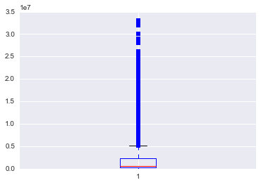

```python
plt.boxplot(salary_df['salary'],0,'rs')
plt.show()
```

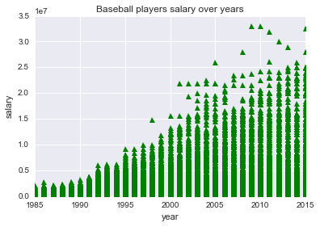

```python
#Plot showing salary of players over years
plt.plot(salary_df['yearID'],salary_df['salary'],'g^')
plt.xlabel("year")
plt.ylabel("salary")
plt.title('Baseball players salary over years')
plt.show()
```

#### From the above plot we could infer that the salary of players gradually increased over years.

```python
appearances_filename='C:/Users/JAYASHREE/Desktop/Data Analyst Nanodegree/Intro in to data analysis/Baseball project/baseballdatabank-master_2016-03-02/baseballdatabank-master/core/Appearances.csv'
```

```python
appearances_df=pd.read_csv(appearances_filename)
```

```python
#Function to find correlation between  2 variables
def correlation(x, y):
    std_x=(x-x.mean())/x.std(ddof=0)
    std_y=(y-y.mean())/y.std(ddof=0)
    return (std_x *std_y).mean()
```

#### Salary data is merged with appearances data to find an effect on games played,batted and appeared with the salary of players

```python
salary_appearance_combine=salary_df.merge(appearances_df,how='inner',on=['yearID','teamID','lgID','playerID'])
salary_appearance_combine.head()
```

|  | yearID | teamID | lgID | playerID | salary | G_all | GS | G_batting | G_defense | G_p | ... | G_2b | G_3b | G_ss | G_lf | G_cf | G_rf | G_of | G_dh | G_ph | G_pr |
| --- | --- | --- | --- | --- | --- | --- | --- | --- | --- | --- | --- | --- | --- | --- | --- | --- | --- | --- | --- | --- | --- |
| 0 | 1985 | ATL | NL | barkele01 | 870000 | 20.0 | 18.0 | 20 | 20.0 | 20 | ... | 0 | 0 | 0 | 0 | 0 | 0 | 0 | 0.0 | 0.0 | 0.0 |
| 1 | 1985 | ATL | NL | bedrost01 | 550000 | 37.0 | 37.0 | 37 | 37.0 | 37 | ... | 0 | 0 | 0 | 0 | 0 | 0 | 0 | 0.0 | 0.0 | 0.0 |
| 2 | 1985 | ATL | NL | benedbr01 | 545000 | 70.0 | 67.0 | 70 | 70.0 | 0 | ... | 0 | 0 | 0 | 0 | 0 | 0 | 0 | 0.0 | 0.0 | 0.0 |
| 3 | 1985 | ATL | NL | campri01 | 633333 | 66.0 | 2.0 | 66 | 66.0 | 66 | ... | 0 | 0 | 0 | 0 | 0 | 0 | 0 | 0.0 | 0.0 | 0.0 |
| 4 | 1985 | ATL | NL | ceronri01 | 625000 | 96.0 | 76.0 | 96 | 90.0 | 0 | ... | 0 | 0 | 0 | 0 | 0 | 0 | 0 | 0.0 | 8.0 | 0.0 |

5 rows × 22 columns

#### Count of missing values in G_all,G_batting,G_defense columns is found

```python
print np.count_nonzero(salary_appearance_combine['G_all'].isnull())
print np.count_nonzero(salary_appearance_combine['G_batting'].isnull())
print np.count_nonzero(salary_appearance_combine['G_defense'].isnull())
```

```
69
0
69
```

#### Missing values are replaced with the mean values of the corresponding colulmn.

```python
#Missing value treatment
salary_appearance_combine['G_all']=salary_appearance_combine['G_all'].fillna(salary_appearance_combine['G_all'].mean())
salary_appearance_combine['G_defense']=salary_appearance_combine['G_defense'].fillna(salary_appearance_combine['G_defense'].mean())
```

```python
salary=salary_appearance_combine['salary']
games_played=salary_appearance_combine['G_all']
games_batted=salary_appearance_combine['G_batting']
games_defended=salary_appearance_combine['G_defense']

print correlation(salary,games_played)
print correlation(salary,games_batted)
print correlation(salary,games_defended)
```

```
0.180535475256
0.168820722269
0.173325324683
```

#### Games played,Games_batted and Games appeared on defense have slight positive linear relationship with salary.

```python
print np.corrcoef(salary,games_played)
```

```
[[ 1.          0.18053548]
 [ 0.18053548  1.        ]]
```

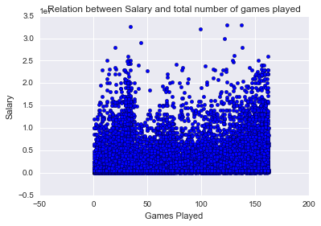

```python
#Scatter plot between salary and total games played
plt.scatter(games_played,salary)
plt.xlabel('Games Played')
plt.ylabel('Salary')
plt.title('Relation between Salary and total number of games played')
plt.show()
```

#### The above plot shows that there exists weak linear relationship between salary and number of games played.

```python
batting_filename='C:/Users/JAYASHREE/Desktop/Data Analyst Nanodegree/Intro in to data analysis/Baseball project/baseballdatabank-master_2016-03-02/baseballdatabank-master/core/Batting.csv'
```

```python
batting_df=pd.read_csv(batting_filename)
```

#### Salary data is merged with batting data to find the impact of runs on salary

```python
salary_runs_combine=salary_df.merge(batting_df,how='inner',on=['yearID','teamID','lgID','playerID'])
salary_runs_combine.head()
```

|  | yearID | teamID | lgID | playerID | salary | stint | G | AB | R | H | ... | RBI | SB | CS | BB | SO | IBB | HBP | SH | SF | GIDP |
| --- | --- | --- | --- | --- | --- | --- | --- | --- | --- | --- | --- | --- | --- | --- | --- | --- | --- | --- | --- | --- | --- |
| 0 | 1985 | ATL | NL | barkele01 | 870000 | 1 | 20 | 17.0 | 0.0 | 0.0 | ... | 0.0 | 0.0 | 1.0 | 0.0 | 7.0 | 0.0 | 0.0 | 0.0 | 0.0 | 0.0 |
| 1 | 1985 | ATL | NL | bedrost01 | 550000 | 1 | 37 | 64.0 | 3.0 | 5.0 | ... | 1.0 | 0.0 | 0.0 | 1.0 | 22.0 | 0.0 | 0.0 | 6.0 | 0.0 | 0.0 |
| 2 | 1985 | ATL | NL | benedbr01 | 545000 | 1 | 70 | 208.0 | 12.0 | 42.0 | ... | 20.0 | 0.0 | 1.0 | 22.0 | 12.0 | 1.0 | 1.0 | 4.0 | 2.0 | 8.0 |
| 3 | 1985 | ATL | NL | campri01 | 633333 | 1 | 66 | 13.0 | 1.0 | 3.0 | ... | 2.0 | 0.0 | 0.0 | 1.0 | 5.0 | 0.0 | 0.0 | 1.0 | 0.0 | 0.0 |
| 4 | 1985 | ATL | NL | ceronri01 | 625000 | 1 | 96 | 282.0 | 15.0 | 61.0 | ... | 25.0 | 0.0 | 3.0 | 29.0 | 25.0 | 1.0 | 1.0 | 0.0 | 4.0 | 15.0 |

5 rows × 23 columns

```python
#count missing values
np.count_nonzero(salary_runs_combine['R'].isnull())
```

```
1877
```

#### There are 1877 rows that contain missing runs scored values.These missing values are replaced by the mean of runs scored by all players

```python
salary_runs_combine['R']=salary_runs_combine['R'].fillna(salary_runs_combine['R'].mean())
```

```python
salary_drawn,runs_scored=salary_runs_combine['salary'],salary_runs_combine['R']
print correlation(salary_drawn,runs_scored)
```

```
0.22331192762
```

#### Correlation shows that there exists a positive linear relationship between runs scored and salary of players.However the relationship is not strong.

```python
np.corrcoef(salary_drawn,runs_scored)
```

```
array([[ 1.        ,  0.22331193],
       [ 0.22331193,  1.        ]])
```

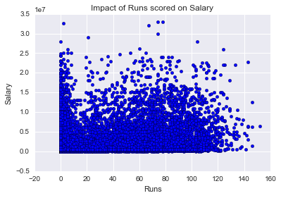

```python
# PLot showing runs scored vs salary
plt.scatter(runs_scored,salary_drawn)
plt.xlabel('Runs')
plt.ylabel('Salary')
plt.title('Impact of Runs scored on Salary')
plt.show()
```

```python
fielding_filename='C:/Users/JAYASHREE/Desktop/Data Analyst Nanodegree/Intro in to data analysis/Baseball project/baseballdatabank-master_2016-03-02/baseballdatabank-master/core/Fielding.csv'
```

```python
fielding_df=pd.read_csv(fielding_filename)
```

#### Salary data is merged with fielding data to find the impact of field position on salary

```python
salary_fielding_combine=salary_df.merge(fielding_df,how='inner',on=['yearID','teamID','lgID','playerID'])
salary_fielding_combine.head()
```

|  | yearID | teamID | lgID | playerID | salary | stint | POS | G | GS | InnOuts | PO | A | E | DP | PB | WP | SB | CS | ZR |
| --- | --- | --- | --- | --- | --- | --- | --- | --- | --- | --- | --- | --- | --- | --- | --- | --- | --- | --- | --- |
| 0 | 1985 | ATL | NL | barkele01 | 870000 | 1 | P | 20 | 18.0 | 221.0 | 2.0 | 9.0 | 1.0 | 0.0 | NaN | NaN | NaN | NaN | NaN |
| 1 | 1985 | ATL | NL | bedrost01 | 550000 | 1 | P | 37 | 37.0 | 620.0 | 13.0 | 23.0 | 4.0 | 3.0 | NaN | NaN | NaN | NaN | NaN |
| 2 | 1985 | ATL | NL | benedbr01 | 545000 | 1 | C | 70 | 67.0 | 1698.0 | 314.0 | 35.0 | 4.0 | 1.0 | 1.0 | 9.0 | 65.0 | 24.0 | 1.0 |
| 3 | 1985 | ATL | NL | campri01 | 633333 | 1 | P | 66 | 2.0 | 383.0 | 7.0 | 13.0 | 4.0 | 3.0 | NaN | NaN | NaN | NaN | NaN |
| 4 | 1985 | ATL | NL | ceronri01 | 625000 | 1 | C | 91 | 76.0 | 2097.0 | 384.0 | 48.0 | 6.0 | 4.0 | 6.0 | 20.0 | 69.0 | 29.0 | 1.0 |

#### Merged data is grouped by field position and the mean salary across each position is found.

```python
position=salary_fielding_combine.groupby('POS')['salary'].mean()
```

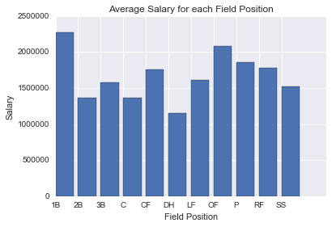

```python
#Plot showing effect of field position on salary
xticks=index=pd.Series(position.index)
x=(range(11))
y=position.values
plt.bar(x,y)
plt.xticks(x,xticks)
plt.xlabel('Field Position')
plt.ylabel('Salary')
plt.title('Average Salary for each Field Position')
plt.show()
```

#### The above plot clearly shows that position 1B yields highest salary while position DH yields lowest salary.

```python
master_filename='C:/Users/JAYASHREE/Desktop/Data Analyst Nanodegree/Intro in to data analysis/Baseball project/baseballdatabank-master_2016-03-02/baseballdatabank-master/core/Master.csv'
```

```python
master_df=pd.read_csv(master_filename)
```

#### Salary data is merged with master data to find an effect of batting hand and age on salary

```python
salary_bathand_combine=salary_df.merge(master_df,how='inner',on=['playerID'])
salary_bathand_combine.head()
```

|  | yearID | teamID | lgID | playerID | salary | birthYear | birthMonth | birthDay | birthCountry | birthState | ... | nameLast | nameGiven | weight | height | bats | throws | debut | finalGame | retroID | bbrefID |
| --- | --- | --- | --- | --- | --- | --- | --- | --- | --- | --- | --- | --- | --- | --- | --- | --- | --- | --- | --- | --- | --- |
| 0 | 1985 | ATL | NL | barkele01 | 870000 | 1955.0 | 7.0 | 27.0 | USA | KY | ... | Barker | Leonard Harold | 225.0 | 77.0 | R | R | 1976-09-14 | 1987-09-26 | barkl001 | barkele01 |
| 1 | 1986 | ATL | NL | barkele01 | 880000 | 1955.0 | 7.0 | 27.0 | USA | KY | ... | Barker | Leonard Harold | 225.0 | 77.0 | R | R | 1976-09-14 | 1987-09-26 | barkl001 | barkele01 |
| 2 | 1987 | ATL | NL | barkele01 | 890000 | 1955.0 | 7.0 | 27.0 | USA | KY | ... | Barker | Leonard Harold | 225.0 | 77.0 | R | R | 1976-09-14 | 1987-09-26 | barkl001 | barkele01 |
| 3 | 1987 | ML4 | AL | barkele01 | 72500 | 1955.0 | 7.0 | 27.0 | USA | KY | ... | Barker | Leonard Harold | 225.0 | 77.0 | R | R | 1976-09-14 | 1987-09-26 | barkl001 | barkele01 |
| 4 | 1988 | ATL | NL | barkele01 | 900000 | 1955.0 | 7.0 | 27.0 | USA | KY | ... | Barker | Leonard Harold | 225.0 | 77.0 | R | R | 1976-09-14 | 1987-09-26 | barkl001 | barkele01 |

5 rows × 28 columns

```python
np.count_nonzero(salary_bathand_combine['bats'].isnull())
```

```
0
```

#### Batting hand details of all players are captured

```python
batting_hand=salary_bathand_combine.groupby('bats').mean()['salary']
```

#### Combined data is grouped by batting hand and the mean salary is found for each batting hand.

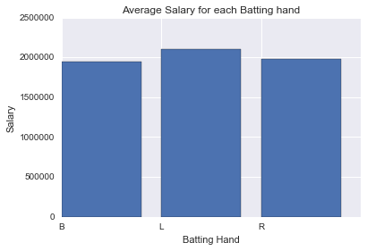

```python
# plot showing mean salary for each batting hand
xticks=pd.Series(batting_hand.index)
x=(range(3))
y=batting_hand.values
plt.bar(x,y)
plt.xticks(x,xticks)
plt.xlabel('Batting Hand')
plt.ylabel('Salary')
plt.title('Average Salary for each Batting hand')
plt.show()
```

#### The plot shows that the average salary of left hand players are slightly higher than the players who use right or both the hands,

```python
#Find age of players
salary_bathand_combine['age']=salary_bathand_combine['yearID']-salary_bathand_combine['birthYear']
salary_bathand_combine.head()
```

|  | yearID | teamID | lgID | playerID | salary | birthYear | birthMonth | birthDay | birthCountry | birthState | ... | nameGiven | weight | height | bats | throws | debut | finalGame | retroID | bbrefID | age |
| --- | --- | --- | --- | --- | --- | --- | --- | --- | --- | --- | --- | --- | --- | --- | --- | --- | --- | --- | --- | --- | --- |
| 0 | 1985 | ATL | NL | barkele01 | 870000 | 1955.0 | 7.0 | 27.0 | USA | KY | ... | Leonard Harold | 225.0 | 77.0 | R | R | 1976-09-14 | 1987-09-26 | barkl001 | barkele01 | 30.0 |
| 1 | 1986 | ATL | NL | barkele01 | 880000 | 1955.0 | 7.0 | 27.0 | USA | KY | ... | Leonard Harold | 225.0 | 77.0 | R | R | 1976-09-14 | 1987-09-26 | barkl001 | barkele01 | 31.0 |
| 2 | 1987 | ATL | NL | barkele01 | 890000 | 1955.0 | 7.0 | 27.0 | USA | KY | ... | Leonard Harold | 225.0 | 77.0 | R | R | 1976-09-14 | 1987-09-26 | barkl001 | barkele01 | 32.0 |
| 3 | 1987 | ML4 | AL | barkele01 | 72500 | 1955.0 | 7.0 | 27.0 | USA | KY | ... | Leonard Harold | 225.0 | 77.0 | R | R | 1976-09-14 | 1987-09-26 | barkl001 | barkele01 | 32.0 |
| 4 | 1988 | ATL | NL | barkele01 | 900000 | 1955.0 | 7.0 | 27.0 | USA | KY | ... | Leonard Harold | 225.0 | 77.0 | R | R | 1976-09-14 | 1987-09-26 | barkl001 | barkele01 | 33.0 |

5 rows × 29 columns

```python
salary_bathand_combine['age'].describe()
```

```
count    25567.000000
mean        29.494661
std          4.222008
min         19.000000
25%         26.000000
50%         29.000000
75%         32.000000
max         82.000000
Name: age, dtype: float64
```

#### Summary statistics of age of players.

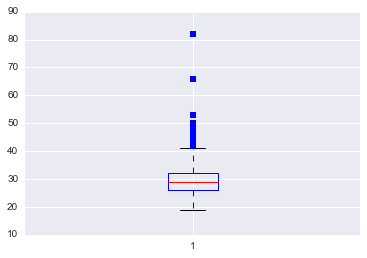

```python
plt.boxplot(salary_bathand_combine['age'],0,'rs')
plt.show()
```

#### Box plot shows that most of the datapoints fall in IQR and there are only few outliers.

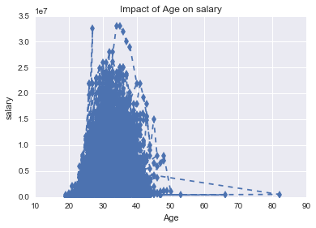

```python
#Varaiation of salary with respect to age
plt.plot(salary_bathand_combine['age'],salary_bathand_combine['salary'],'d--')
plt.xlabel("Age")
plt.ylabel("salary")
plt.title('Impact of Age on salary')
plt.show()
```

#### The plot shows that as age increases from 20 to 35 salary increases and salary tends to decrease after reaching peak at 35years(approximately)

```python
np.corrcoef(salary_bathand_combine['age'],salary_bathand_combine['salary'])
```

```
array([[ 1.        ,  0.32476597],
       [ 0.32476597,  1.        ]])
```

#### As age increases salary increases till 35 showing positive linear relationship while beyond 35 as age increases salary decreases showing negative linear relationship.As age of most players fall in the range 20-40 overall effct is positive with respect to salary.

#### I have analyzed each questions and some of my hypothesis are correct while few of them are wrong.

### Questions where Hypothesis Retained

#### Total runs scored by a player does have a positve impact on his salary.However the impact is not stronger.

#### Field position does have an impact on salary.We have seen average salary across different field positions.The difference in salary between highest and lowest average salary position is notable.

#### Age of a player has an effect on salary.From the plot we could see that till some points it has positive linear relationship beyond which it goes to negative linear relationship.But the overall effect is positive as age of most players fall under posive relationship bucket.

### Questions where Hypothesis failed to prove

#### Total games played,games where player batted and where he appeared on defense doesn't have strong postive linear relationship with salary.

#### Players batting hand doesn't have an effect on salary.Average salary for left,right and both hands are almost same